# Efficiency of Public Expenditure in Education: Peru Case

Two Step Analysis: Data Envelopment Analysis (DEA) and Panel Data

Created by: Eduardo Paredes

10/12/2021

# Data and Variables

- tasadesnutricion: Chronic malnutrition, kids under 5 years old, by region, 2009-2019, Source: INEI (Percentage)
- docentes: Teachers of public sector, by region, 2008-2009. (number)
- alumnosmatriculados: Students of secundary education, by region, 2009-2019 (thousands)
- analfabetismo: Rate of analfabetism of population under 15 years old, by region, 2008 -2019 (Percentage)
- gastopublico: Public expenditure by student en regular basic education, by educational level and region, 2008-2018 (nuevos soles, PEN)
- pbiregiones: GDP per capita. by year and region, 2007-2020 (constant prices 2007 thousands of soles), then divided by pobtotal.
- pobtotal: Total population registered and omitted, by census year/inter census years estimated (number)
- poburb: Census population of urban areas, by region and census year (number)
- tasamatricula: School enrollment of secondary education between 12 and 16 years old, by region, 2008-2019 (Rate)
- tasaconclusion: Percentage of people that concluded secondary education, population older than 15 years old, by region, 2008-2019 (percentage)
- complectora: Mean of grade of reading. Secondary level, by region. Educational Census of Peru(Number)
- matematica: Mean of grade of mathematics. Secondary level, by region. Educational Census of Peru (Number)
- alumDoc: Rate of Students per teacher, by region and by year (rate)
- nivelUrb: Percentage of urban population. popUrb divided by popTotal (percentage)

Only 2015, 2016 and 2018 were taken as sample due to Educational Census limitations.

# Logic Behind

The study aims to rank the regions of Peru by its efficiency expenditure in Education. This variable is calculated by DEA procedure, where the output is compLectora, matematica, tasaMatricula, tasaConclusion and the input is gastoPublico.

After DEA, the paper seeks to find the impact of some variables on the efficiency using a Panel Data.

Further econometric, theory explanation and details were explained in a meeting.

# Data Envelopment Analysis (DEA) - First Step

## Calculus of Efficiency (DEA)

Efficiency by region and year

| Departamento | 2015 | 2016 | 2018 | Promedio | Ranking |
| --- | --- | --- | --- | --- | --- |
| Tumbes | 0.952 | 0.949 | 0.954 | 0.952 | 1 |
| Región Lima | 0.954 | 0.934 | 0.962 | 0.950 | 2 |
| Ica | 0.946 | 0.913 | 0.961 | 0.940 | 3 |
| Puno | 0.906 | 0.931 | 0.970 | 0.936 | 4 |
| Arequipa | 0.917 | 0.930 | 0.955 | 0.934 | 5 |
| Madre de Dios | 0.919 | 0.938 | 0.942 | 0.933 | 6 |
| Moquegua | 0.921 | 0.907 | 0.953 | 0.927 | 7 |
| Provincia de Lima | 0.935 | 0.897 | 0.950 | 0.927 | 8 |
| Piura | 0.919 | 0.901 | 0.939 | 0.920 | 9 |
| Tacna | 0.922 | 0.900 | 0.938 | 0.920 | 10 |
| Callao | 0.917 | 0.898 | 0.940 | 0.918 | 11 |
| Cusco | 0.938 | 0.901 | 0.916 | 0.918 | 12 |
| Áncash | 0.938 | 0.890 | 0.919 | 0.916 | 13 |
| Huancavelica | 0.914 | 0.898 | 0.921 | 0.911 | 14 |
| Loreto | 0.886 | 0.890 | 0.907 | 0.894 | 15 |
| Apurímac | 0.882 | 0.859 | 0.933 | 0.891 | 16 |
| Ayacucho | 0.888 | 0.868 | 0.912 | 0.889 | 17 |
| Pasco | 0.864 | 0.843 | 0.925 | 0.877 | 18 |
| Ucayali | 0.822 | 0.898 | 0.892 | 0.871 | 19 |
| Lambayeque | 0.845 | 0.874 | 0.887 | 0.869 | 20 |
| Junín | 0.860 | 0.840 | 0.905 | 0.868 | 21 |
| La Libertad | 0.873 | 0.810 | 0.879 | 0.854 | 22 |
| San Martín | 0.871 | 0.802 | 0.862 | 0.845 | 23 |
| Cajamarca | 0.854 | 0.798 | 0.856 | 0.836 | 24 |
| Amazonas | 0.815 | 0.728 | 0.889 | 0.811 | 25 |
| Huánuco | 0.806 | 0.792 | 0.836 | 0.811 | 26 |

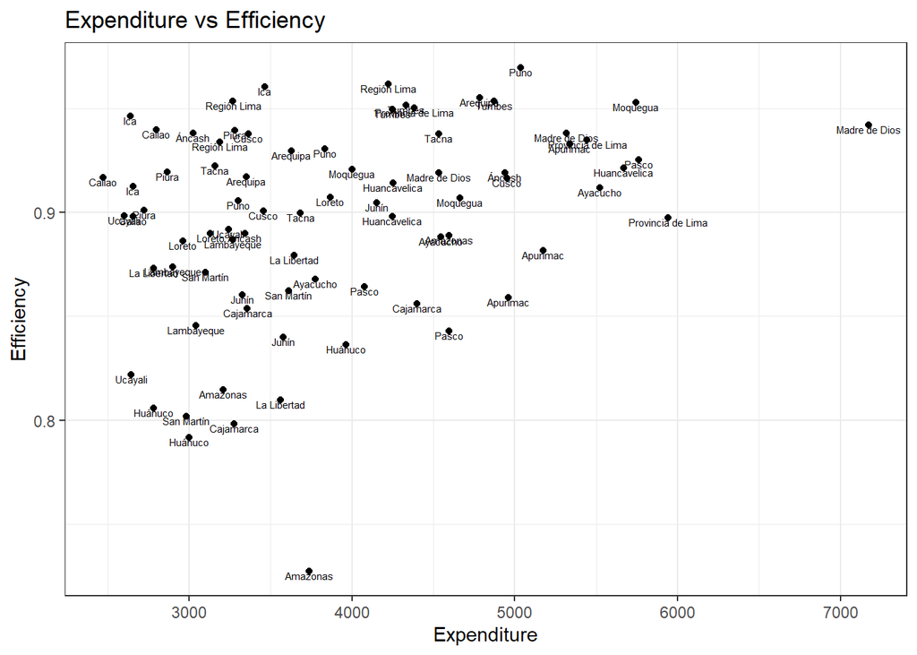

# Panel Data - Second Step

## Analysis of Correlations

Pearson Correlation

|  | deaRobust | analfabetismo | pbiRegiones | tasaDesnutricion | alumDoc | nivelUrb |
| --- | --- | --- | --- | --- | --- | --- |
| deaRobust | 1.00 | -0.40 | 0.41 | -0.48 | -0.05 | 0.47 |
| analfabetismo | -0.40 | 1.00 | -0.42 | 0.75 | -0.08 | -0.91 |
| pbiRegiones | 0.41 | -0.42 | 1.00 | -0.58 | -0.37 | 0.47 |
| tasaDesnutricion | -0.48 | 0.75 | -0.58 | 1.00 | -0.05 | -0.84 |
| alumDoc | -0.05 | -0.08 | -0.37 | -0.05 | 1.00 | 0.15 |
| nivelUrb | 0.47 | -0.91 | 0.47 | -0.84 | 0.15 | 1.00 |

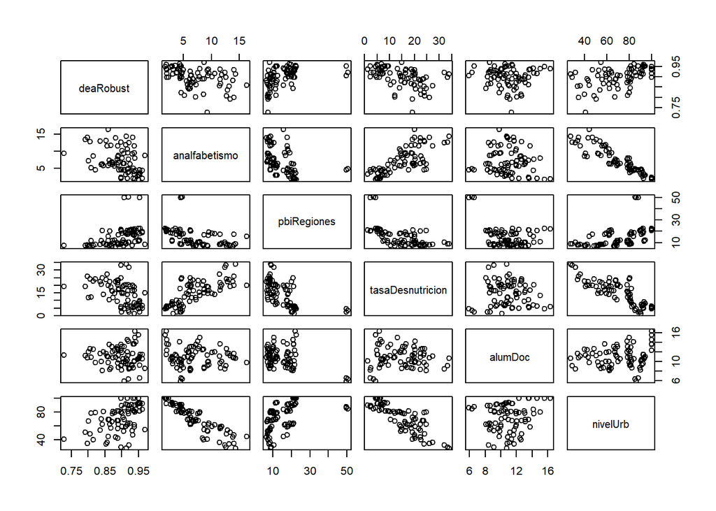

## Variance Inflation Factor

### With nivelUrb

```
##    data$analfabetismo         data$nivelUrb          data$alumDoc
##              6.124719              9.605255              1.407076
## data$tasaDesnutricion      data$pbiRegiones
##              4.125170              2.020256
```

### Withouth nivelUrb

```
##    data$analfabetismo          data$alumDoc data$tasaDesnutricion
##              2.285715              1.331700              2.986365
##      data$pbiRegiones
##              2.008506
```

## Tests

```
##
##  Hausman Test
##
## data:  data$deaRobust ~ data$alumDoc + data$analfabetismo + data$pbiRegiones +  ...
## chisq = 20.31, df = 4, p-value = 0.0004338
## alternative hypothesis: one model is inconsistent
```

```
##
##  Breusch-Pagan LM test for cross-sectional dependence in panels
##
## data:  data$deaRobust ~ data$alumDoc + data$analfabetismo + data$pbiRegiones +     data$tasaDesnutricion
## chisq = 475.41, df = 325, p-value = 9.875e-08
## alternative hypothesis: cross-sectional dependence
```

```
##
##  Pesaran CD test for cross-sectional dependence in panels
##
## data:  data$deaRobust ~ data$alumDoc + data$analfabetismo + data$pbiRegiones +     data$tasaDesnutricion
## z = 0.27844, p-value = 0.7807
## alternative hypothesis: cross-sectional dependence
```

```
##
##  studentized Breusch-Pagan test
##
## data:  plm_within_2
## BP = 5.0503, df = 4, p-value = 0.2822
```

```
##
##  studentized Breusch-Pagan test
##
## data:  plm_random_2
## BP = 5.0503, df = 4, p-value = 0.2822
```